# DEM 7283 - Multiple Imputation & Missing Data

Corey Sparks, PhD

29 March, 2022

This example will illustrate typical aspects of dealing with missing data. Topics will include: Mean imputation, modal imputation for categorical data, and multiple imputation of complex patterns of missing data.

For this example I am using 2020 CDC Behavioral Risk Factor Surveillance System (BRFSS) SMART county data. [Link](https://www.cdc.gov/brfss/smart/smart_2020.html)

## Missing data

- Every time we ask a question on a survey, there are a variety of reasons why we may fail to get a complete response
- This is a cause for concern for those using survey data

### Reasons for missing data

Total nonresponse

- This is where a respondent completely refuses to participate in the survey, or some other barrier prevents them from participating (not at home, ill, disability)
- This is usually accounted for by survey weights
- **Noncoverage**
- When an individual is not included in the survey’s sampling frame
- Usually adjusted for in the weights
- **Item nonresponse**
- When a respondent fails to provide an acceptable response to a survey question
- Could be refusal
- Could be “I don’t know”
- Gould give an inconsistent response
- The interviewer could fail to ask the question
- **Partial nonresponse**
- Somewhere between total nonresponse and item nonresponse
- Respondent could end the interview
- e.g. Incomplete responses for a wave in a panel study
- Can be dealt with by using weights, which eliminates respondent with partial responses
- Can be dealt with by imputation, where the value is filled in by data editors

### Types of missing data

- **Missing completely at random (MCAR)**
- Missing values do not depend on any characteristic of an individual
- Missing at random (MAR)
- Missing values do not relate to the item of interest itself, but it could be related to another characteristic of the respondent
- These two are said to be “ignorable”
- **Missing Not at random (MNAR)**
- Think of a question on satisfaction, those that are extremely dissatisfied may be less likely to respond, so the results may be biased because they don’t include those folks
- This is “non-ignorable”

### How can we tell is a variable is MCAR?

- One way to estimate if an element is MCAR or MAR is to form a missing data variable (1=missing, 0=nonmissing) and estimate a logistic regression for that variable using key characteristics of a respondent
- If all these characteristics show insignificant effects, we can pretty much assume the element is MCAR/MAR

### What does the computer do?

- Typically the computer will do one of two things
- Delete the entire case if any variables in the equation are missing, this is called *listwise deletion*
- delete the case for a particular comparison, this is called *pairwise deletion*
- Both of these lead to fewer cases for entire models or for particular tests

### How can we impute a missing value?

- There are easy ways and hard ways, but the answer is yes.
- Easy ways == bad ways
- Mean substitution
- Plugs in the value for the average response for a missing value for all individuals
- If a large % of the respondents are missing the values (say >20%) the mean could be not estimated very well
- The variance of the variable will be driven down, if everyone who is missing is given the mean
- Can lead to lower effect sizes/betas in the models using the data

### Regression imputation

- Multiple Imputation will use other characteristics of individuals with complete observations to predict the missing value for the missing person
- This would use the observed characteristics of the respondent to predict their missing value
- Think regression!
- Income is a good variable like this
- People don’t like to report their income, but they may be willing to report their education, and other characteristics
- We can use those to predict their income
- This is sensitive to assumptions of the regression model being used!

### Multiple Imputation

- This works like the regression imputation method, but applies it recursively to all patterns of missing data
- Typically this will be done several times, usually 5 is the rule most programs use, and the differences in the imputations are compared across runs
- i.e. if we impute the values then run a regression for the outcome, how sensitive are the results of the model to the imputation
- There are various ways to do this, and it depends on the scale of the variable

### Hot deck imputation

- Find a set of variables that are associated with your outcome
- If there are cases similar to yours (i.e. they are similar on the non-missing variables), you can plug in their variable of interest for the missing case
- This is what the census did for years

### Predictive mean matching

- Regress Y on the observed X’s for the complete cases
- Form fitted or “predicted” values
- Replace the missing values with a fitted value from the regression from non-missing observations who are “close” to the missing cases
- i.e. replace the missing values with fitted values from similar individuals

```r
library(car)
library(mice)
library(ggplot2)
library(dplyr)
```

```r
#load brfss
brfss20<- readRDS(url("https://github.com/coreysparks/DEM7283/blob/master/data/brfss20sm.rds?raw=true"))
### Fix variable names
names(brfss20) <- tolower(gsub(pattern = "_",replacement =  "",x =  names(brfss20)))

### Generate smaller sample for teaching examples
samps<- sample(1:dim(brfss20)[1], size = 10000, replace = F)
brfss20<- brfss20[samps,]

#Poor or fair self rated health
brfss20$badhealth<-Recode(brfss20$genhlth,
                           recodes="4:5=1; 1:3=0; else=NA")

#sex
brfss20$male<-as.factor(ifelse(brfss20$sex==1,
                                "Male",
                                "Female"))

#Age cut into intervals
brfss20$agec<-cut(brfss20$age80,
                   breaks=c(0,24,39,59,79,99))

#race/ethnicity
brfss20$black<-Recode(brfss20$racegr3,
                       recodes="2=1; 9=NA; else=0")
brfss20$white<-Recode(brfss20$racegr3,
                       recodes="1=1; 9=NA; else=0")
brfss20$other<-Recode(brfss20$racegr3,
                       recodes="3:4=1; 9=NA; else=0")
brfss20$hispanic<-Recode(brfss20$racegr3,
                          recodes="5=1; 9=NA; else=0")

brfss20$race_eth<-Recode(brfss20$racegr3,
                          recodes="1='nhwhite'; 2='nh_black'; 3='nh_other';4='nh_multirace'; 5='hispanic'; else=NA",
                          as.factor = T)

#insurance
brfss20$ins<-Recode(brfss20$hlthpln1,
                     recodes ="7:9=NA; 1=1;2=0")

#income grouping
brfss20$inc<-ifelse(brfss20$incomg==9,
                     NA,
                     brfss20$incomg)

#education level
brfss20$educ<-Recode(brfss20$educa,
                      recodes="1:2='0Prim'; 3='1somehs'; 4='2hsgrad'; 5='3somecol'; 6='4colgrad';9=NA",
                      as.factor=T)

#brfss20$educ<-relevel(brfss20$educ, ref='2hsgrad')

#employment
brfss20$employ<-Recode(brfss20$employ1,
                        recodes="1:2='Employed'; 2:6='nilf'; 7='retired'; 8='unable'; else=NA",
                        as.factor=T)

brfss20$employ<-relevel(brfss20$employ,
                         ref='Employed')

#marital status
brfss20$marst<-Recode(brfss20$marital,
                       recodes="1='married'; 2='divorced'; 3='widowed'; 4='separated'; 5='nm';6='cohab'; else=NA",
                       as.factor=T)

brfss20$marst<-relevel(brfss20$marst,
                        ref='married')

#Age cut into intervals
brfss20$agec<-cut(brfss20$age80,
                   breaks=c(0,29,39,59,79,99))

brfss20$ageg<-factor(brfss20$ageg)

#BMI, in the brfss20a the bmi variable has 2 implied decimal places, so we must divide by 100 to get real bmi's

brfss20$bmi<-brfss20$bmi5/100

brfss20$obese<-ifelse(brfss20$bmi>=30,
                       1,
                       0)
#smoking currently
brfss20$smoke<-Recode(brfss20$smoker3,
                       recodes="1:2 ='Current'; 3 ='Former';4 ='NeverSmoked'; else = NA",
                       as.factor=T)

brfss20$smoke<-relevel(brfss20$smoke,
                        ref = "NeverSmoked")
```

Now, we can get a general idea of the missingness of these variables by just using `summary(brfss20)`

```r
summary(brfss20[, c("ins", "smoke",  "bmi", "badhealth", "race_eth",  "educ", "employ", "marst", "inc")])
```

```
##       ins                 smoke           bmi          badhealth
##  Min.   :0.0000   NeverSmoked:5850   Min.   :12.83   Min.   :0.0000
##  1st Qu.:1.0000   Current    :1131   1st Qu.:23.91   1st Qu.:0.0000
##  Median :1.0000   Former     :2449   Median :27.10   Median :0.0000
##  Mean   :0.9144   NA's       : 570   Mean   :28.11   Mean   :0.1317
##  3rd Qu.:1.0000                      3rd Qu.:31.01   3rd Qu.:0.0000
##  Max.   :1.0000                      Max.   :93.97   Max.   :1.0000
##  NA's   :54                          NA's   :1105    NA's   :31
##          race_eth          educ           employ           marst
##  hispanic    :1057   0Prim   : 198   Employed:5311   married  :5060
##  nh_black    : 967   1somehs : 394   nilf    :1394   cohab    : 396
##  nh_multirace: 176   2hsgrad :2386   retired :2623   divorced :1222
##  nh_other    : 460   3somecol:2591   unable  : 477   nm       :2062
##  nhwhite     :7105   4colgrad:4390   NA's    : 195   separated: 209
##  NA's        : 235   NA's    :  41                   widowed  : 942
##                                                      NA's     : 109
##       inc
##  Min.   :1.000
##  1st Qu.:3.000
##  Median :5.000
##  Mean   :4.035
##  3rd Qu.:5.000
##  Max.   :5.000
##  NA's   :2021
```

Which shows that, among these recoded variables, `inc` , the income variable, 2021 people in the BRFSS, or 20.21% of the sample.

The lowest number of missings is in the bad health variable, which only has 0.31% missing.

### Mean imputation

Now, i’m going to illustrate mean imputation of a continuous variable, BMI.

```r
#I'm going to play with 3 outcomes, bmi, having a regular doctor and income category
summary(brfss20$bmi)
```

```
##    Min. 1st Qu.  Median    Mean 3rd Qu.    Max.    NA's
##   12.83   23.91   27.10   28.11   31.01   93.97    1105
```

```r
#what happens when we replace the missings with the mean?
brfss20$bmi.imp.mean<-ifelse(is.na(brfss20$bmi)==T, mean(brfss20$bmi, na.rm=T), brfss20$bmi)

mean(brfss20$bmi, na.rm=T)
```

```
## [1] 28.1084
```

```r
mean(brfss20$bmi.imp.mean) #no difference!
```

```
## [1] 28.1084
```

```r
fit<-lm(bmi~inc+agec+educ+race_eth, brfss20)
```

```r
median(brfss20$bmi, na.rm=T)
```

```
## [1] 27.1
```

```r
median(brfss20$bmi.imp.mean) #slight difference
```

```
## [1] 27.82
```

```r
var(brfss20$bmi, na.rm=T)
```

```
## [1] 38.325
```

```r
var(brfss20$bmi.imp.mean) # more noticeable difference!
```

```
## [1] 34.08966
```

So what we see here, is that imputing with the mean does nothing to central tendency (when measured using the mean, but does affect the median slightly), but it does reduce the variance in the outcome. This is because you’re replacing all missing cases with the most likely value (the mean), so you’re artificially deflating the variance. That’s not good.

We can see this in a histogram, where the imputed values increase the peak in the distribution:

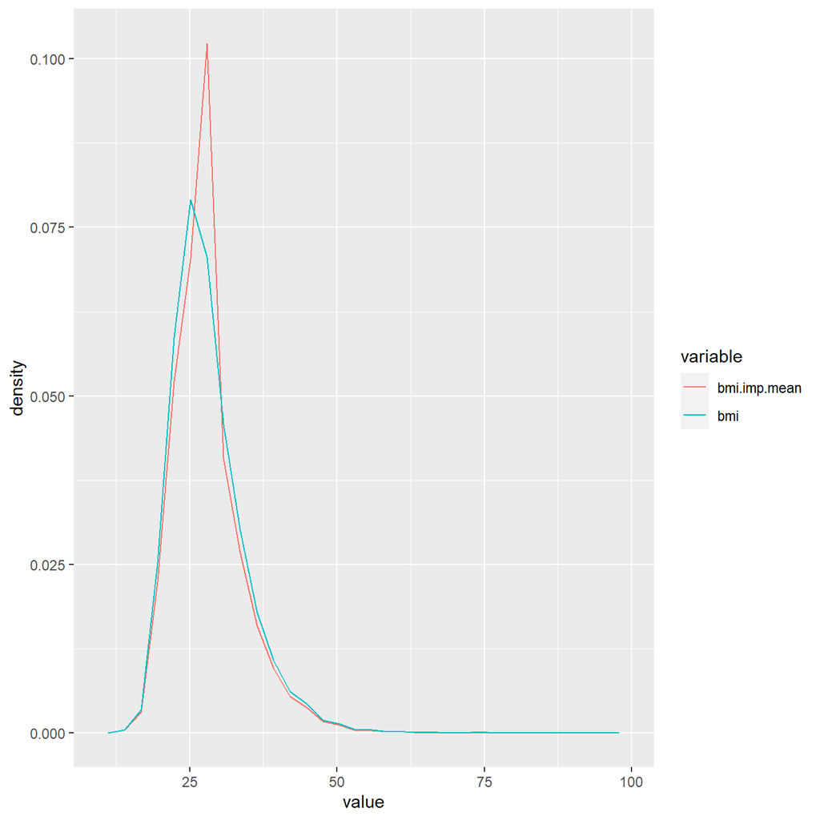

```r
#plot the histogram
library(reshape2)

brfss20%>%
  select(bmi.imp.mean, bmi)%>%
  melt()%>%
  ggplot()+geom_freqpoly(aes(x = value,
     y = ..density.., colour = variable))
```

### Modal imputation for categorical data

If we have a categorical variable, an easy way to impute the values is to use modal imputation, or impute cases with the mode, or most common value. It doesn’t make sense to use the mean, because what would that mean for a categorical variable?

```r
table(brfss20$employ)
```

```
##
## Employed     nilf  retired   unable
##     5311     1394     2623      477
```

```r
#find the most common value
mcv.employ<-factor(names(which.max(table(brfss20$employ))), levels=levels(brfss20$employ))
mcv.employ
```

```
## [1] Employed
## Levels: Employed nilf retired unable
```

```r
#impute the cases
brfss20$employ.imp<-as.factor(ifelse(is.na(brfss20$employ)==T, mcv.employ, brfss20$employ))
levels(brfss20$employ.imp)<-levels(brfss20$employ)

prop.table(table(brfss20$employ))
```

```
##
##   Employed       nilf    retired     unable
## 0.54166242 0.14217236 0.26751657 0.04864865
```

```r
prop.table(table(brfss20$employ.imp))
```

```
##
## Employed     nilf  retired   unable
##   0.5506   0.1394   0.2623   0.0477
```

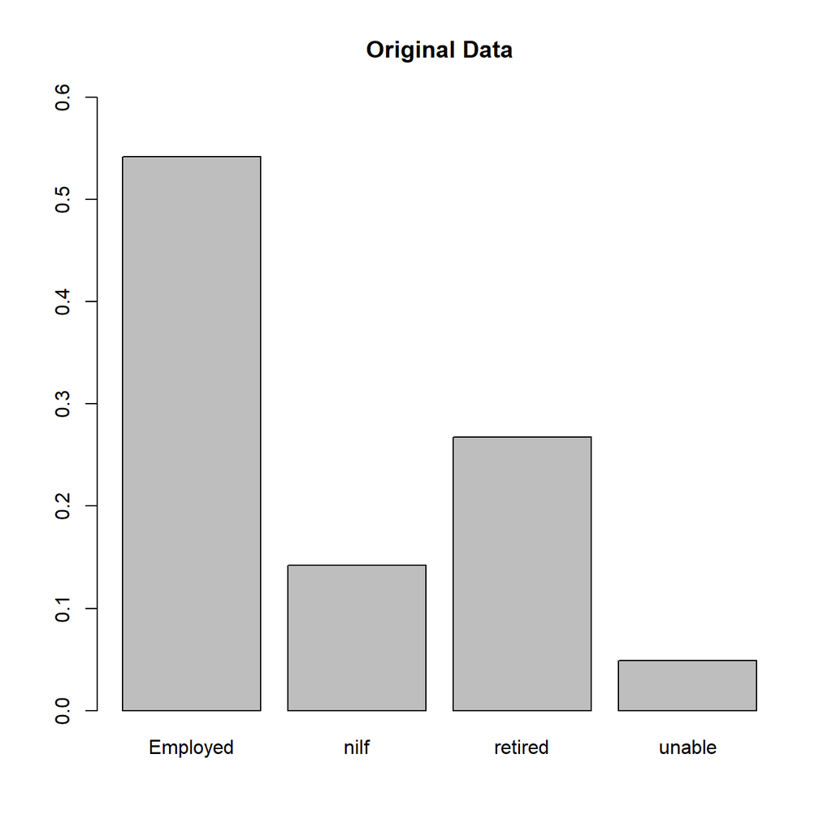

```r
barplot(prop.table(table(brfss20$employ)), main="Original Data", ylim=c(0, .6))
```

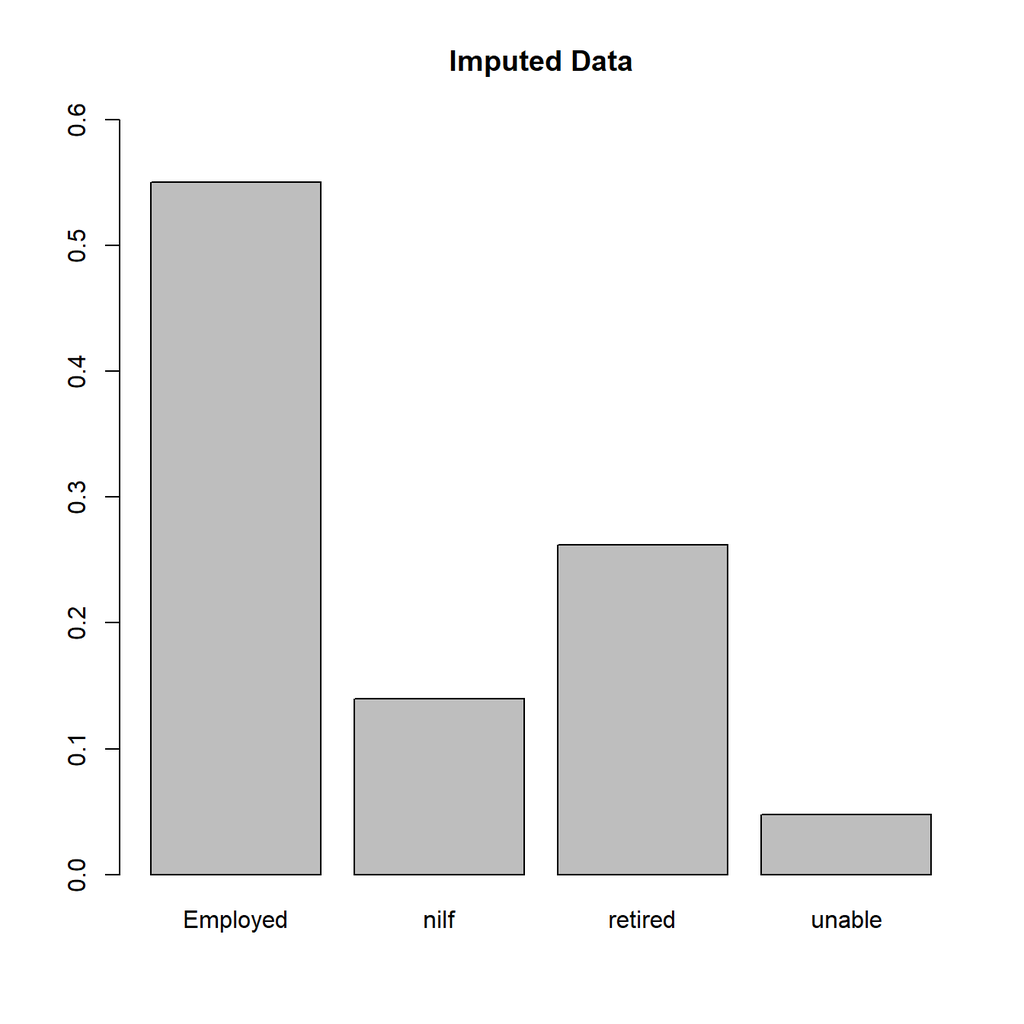

```r
barplot(prop.table(table(brfss20$employ.imp)), main="Imputed Data",ylim=c(0, .6))
```

Which doesn’t look like much of a difference because only 195 people were missing. Now let’s try modal imputation on income group:

```r
table(brfss20$inc)
```

```
##
##    1    2    3    4    5
##  529 1097  652  986 4715
```

```r
#find the most common value
mcv.inc<-factor(names(which.max(table(brfss20$inc))), levels = levels(factor(brfss20$inc)))
mcv.inc
```

```
## [1] 5
## Levels: 1 2 3 4 5
```

```r
#impute the cases
brfss20$inc.imp<-as.factor(ifelse(is.na(brfss20$inc)==T, mcv.inc, brfss20$inc))
levels(brfss20$inc.imp)<-levels(as.factor(brfss20$inc))

prop.table(table(brfss20$inc))
```

```
##
##          1          2          3          4          5
## 0.06629903 0.13748590 0.08171450 0.12357438 0.59092618
```

```r
prop.table(table(brfss20$inc.imp))
```

```
##
##      1      2      3      4      5
## 0.0529 0.1097 0.0652 0.0986 0.6736
```

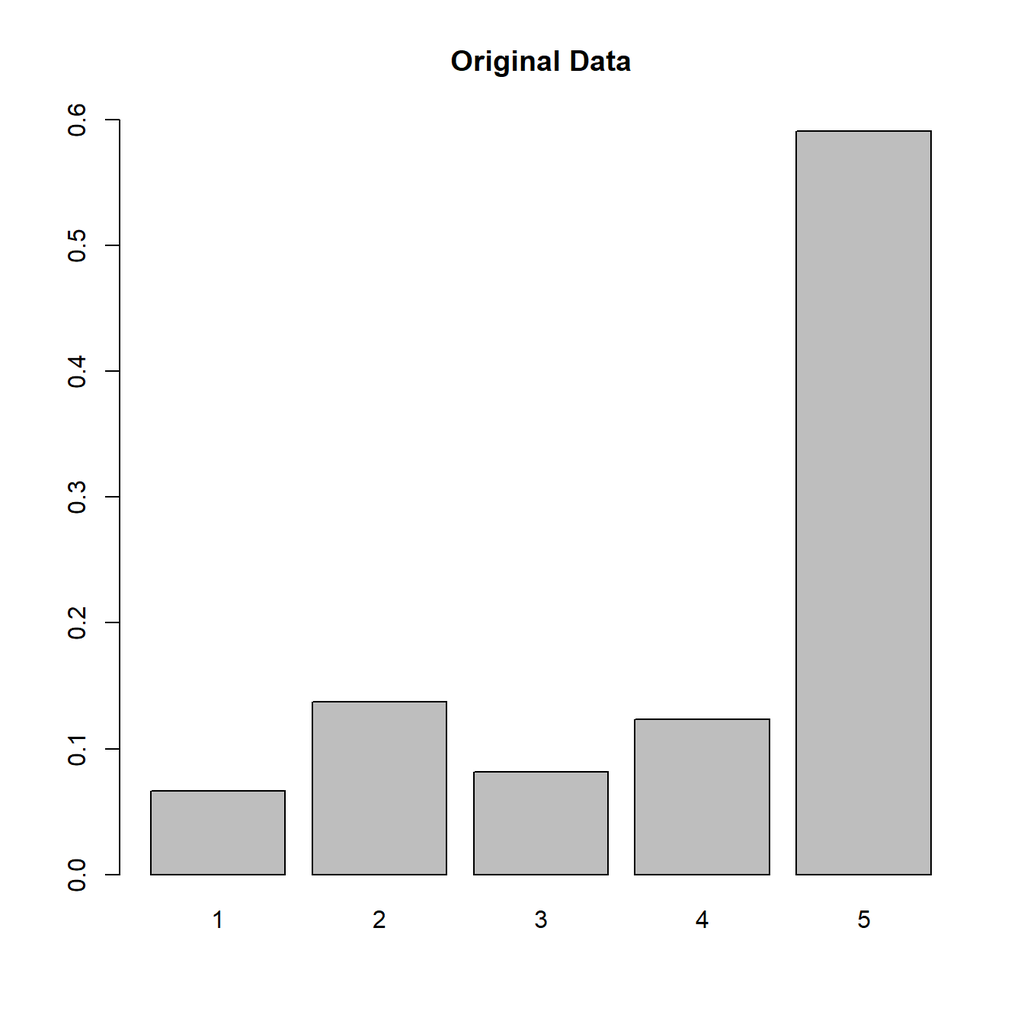

```r
barplot(prop.table(table(brfss20$inc)), main="Original Data", ylim=c(0, .6))
```

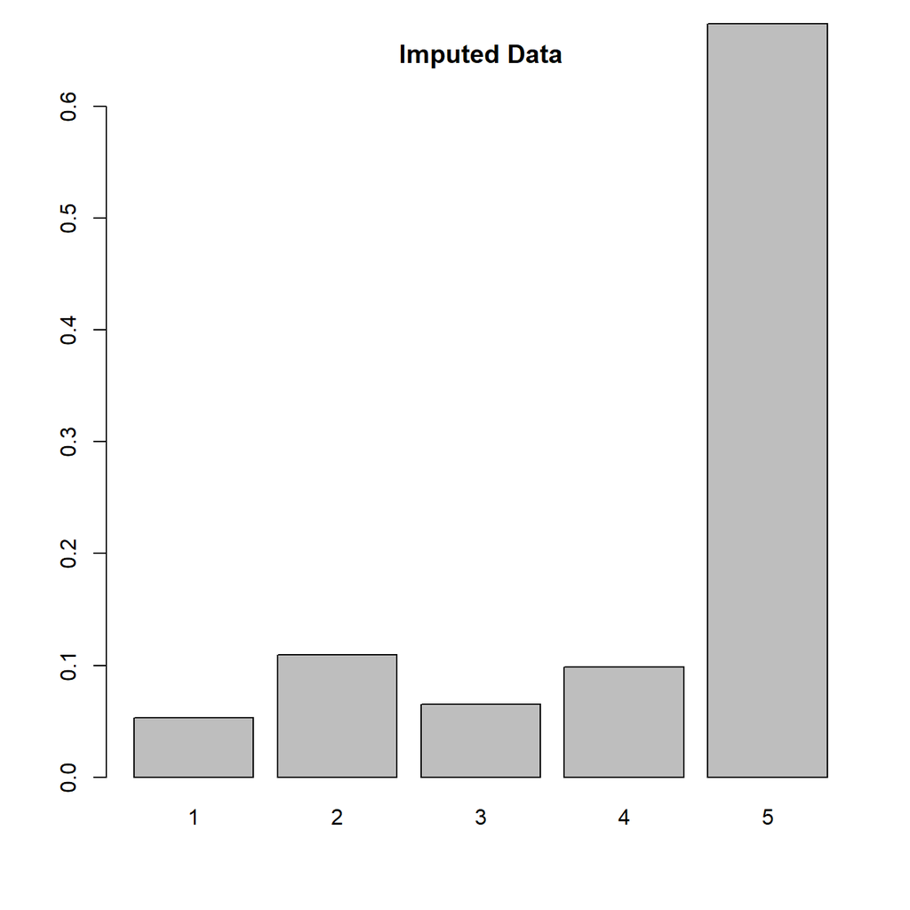

```r
barplot(prop.table(table(brfss20$inc.imp)), main="Imputed Data", ylim=c(0, .6))
```

Which shows how dramatically we alter the distribution of the variable by imputing at the mode.

## Testing for MAR

### Flag variables

We can construct a flag variable. This is a useful exercise to see whether we have missing at random within the data:

```r
fit1<-lm(bmi~is.na(inc), data=brfss20)
fit2<-lm(bmi~is.na(educ), data=brfss20)
fit3<-lm(bmi~is.na(race_eth), data=brfss20)
summary(fit1)
```

```
##
## Call:
## lm(formula = bmi ~ is.na(inc), data = brfss20)
##
## Residuals:
##     Min      1Q  Median      3Q     Max
## -15.441  -4.092  -1.011   2.919  65.699
##
## Coefficients:
##                Estimate Std. Error t value Pr(>|t|)
## (Intercept)    28.27081    0.07154 395.194  < 2e-16 ***
## is.na(inc)TRUE -1.00882    0.17829  -5.658 1.58e-08 ***
## ---
## Signif. codes:  0 '***' 0.001 '**' 0.01 '*' 0.05 '.' 0.1 ' ' 1
##
## Residual standard error: 6.18 on 8893 degrees of freedom
##   (1105 observations deleted due to missingness)
## Multiple R-squared:  0.003587,   Adjusted R-squared:  0.003475
## F-statistic: 32.02 on 1 and 8893 DF,  p-value: 1.576e-08
```

```r
summary(fit2)
```

```
##
## Call:
## lm(formula = bmi ~ is.na(educ), data = brfss20)
##
## Residuals:
##     Min      1Q  Median      3Q     Max
## -15.279  -4.199  -1.009   2.901  65.861
##
## Coefficients:
##                 Estimate Std. Error t value Pr(>|t|)
## (Intercept)      28.1094     0.0657 427.854   <2e-16 ***
## is.na(educ)TRUE  -0.5840     1.5999  -0.365    0.715
## ---
## Signif. codes:  0 '***' 0.001 '**' 0.01 '*' 0.05 '.' 0.1 ' ' 1
##
## Residual standard error: 6.191 on 8893 degrees of freedom
##   (1105 observations deleted due to missingness)
## Multiple R-squared:  1.499e-05,  Adjusted R-squared:  -9.746e-05
## F-statistic: 0.1333 on 1 and 8893 DF,  p-value: 0.7151
```

```r
summary(fit3)
```

```
##
## Call:
## lm(formula = bmi ~ is.na(race_eth), data = brfss20)
##
## Residuals:
##     Min      1Q  Median      3Q     Max
## -15.269  -4.189  -1.049   2.911  65.871
##
## Coefficients:
##                     Estimate Std. Error t value Pr(>|t|)
## (Intercept)         28.09930    0.06624 424.192   <2e-16 ***
## is.na(race_eth)TRUE  0.50294    0.49237   1.021    0.307
## ---
## Signif. codes:  0 '***' 0.001 '**' 0.01 '*' 0.05 '.' 0.1 ' ' 1
##
## Residual standard error: 6.191 on 8893 degrees of freedom
##   (1105 observations deleted due to missingness)
## Multiple R-squared:  0.0001173,  Adjusted R-squared:  4.878e-06
## F-statistic: 1.043 on 1 and 8893 DF,  p-value: 0.3071
```

And indeed we see that those with missing incomes have significantly lower bmi’s. This implies that bmi may not be missing at random with respect to income. This is a good process to go through when you are analyzing if your data are missing at random or not.

### Multiple Imputation

These days, these types of imputation have been far surpassed by more complete methods that are based upon regression methods. These methods are generally referred to as multiple imputation, because we are really interested in imputing multiple variables simultaneously. Instead of reviewing this perspective here, I suggest you have a look at Joe Schafer’s [site](http://sites.stat.psu.edu/~jls/mifaq.html) that gives a nice treatment of the subject. Here, I will use the imputation techniques in the `mice` library in R, which you can read about [here](http://www.jstatsoft.org/v45/i03/paper).

I have used these in practice in publications and generally like the framework the library uses. Another popular technique is in the `Amelia` library of [Gary King](http://gking.harvard.edu/amelia), which I haven’t used much. If you are serious about doing multiple imputation it would be advised to investigate multiple methodologies.

To begin, I explore the various patterns of missingness in the data. The `md.pattern` function in `mice` does this nicely. Here, each row corresponds to a particular pattern of missingness (1 = observed, 0=missing)

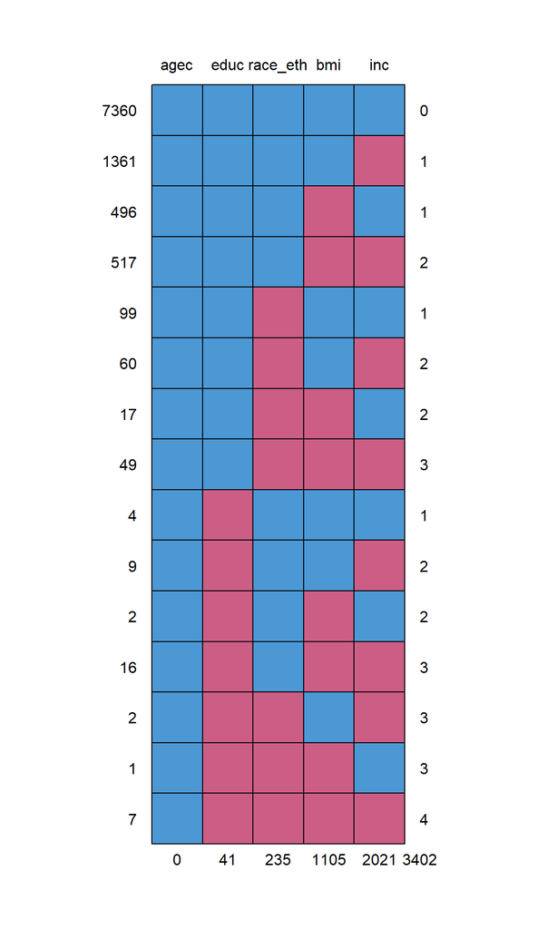

```
##      agec educ race_eth  bmi  inc
## 7360    1    1        1    1    1    0
## 1361    1    1        1    1    0    1
## 496     1    1        1    0    1    1
## 517     1    1        1    0    0    2
## 99      1    1        0    1    1    1
## 60      1    1        0    1    0    2
## 17      1    1        0    0    1    2
## 49      1    1        0    0    0    3
## 4       1    0        1    1    1    1
## 9       1    0        1    1    0    2
## 2       1    0        1    0    1    2
## 16      1    0        1    0    0    3
## 2       1    0        0    1    0    3
## 1       1    0        0    0    1    3
## 7       1    0        0    0    0    4
##         0   41      235 1105 2021 3402
```

```r
#look at the patterns of missingness
md.pattern(brfss20[,c("bmi", "inc", "agec","educ","race_eth")])
```

The first row shows the number of observations in the data that are complete (first row).

The second row shows the number of people who are missing *only* the inc variable.

Rows that have multiple 0’s in the columns indicate missing data patterns where multiple variables are missing.

The bottom row tells how many total people are missing each variable, in *ANY* combination with other variables.

If you want to see how pairs of variables are missing together, the `md.pairs()` function will show this.

A pair of variables can have exactly four missingness patterns: Both variables are observed (pattern `rr`), the first variable is observed and the second variable is missing (pattern `rm`), the first variable is missing and the second variable is observed (pattern `mr`), and both are missing (pattern `mm`).

```r
md.pairs(brfss20[,c("bmi", "inc", "agec","educ","race_eth")])
```

```
## $rr
##           bmi  inc  agec educ race_eth
## bmi      8895 7463  8895 8880     8734
## inc      7463 7979  7979 7972     7862
## agec     8895 7979 10000 9959     9765
## educ     8880 7972  9959 9959     9734
## race_eth 8734 7862  9765 9734     9765
##
## $rm
##           bmi  inc agec educ race_eth
## bmi         0 1432    0   15      161
## inc       516    0    0    7      117
## agec     1105 2021    0   41      235
## educ     1079 1987    0    0      225
## race_eth 1031 1903    0   31        0
##
## $mr
##           bmi inc agec educ race_eth
## bmi         0 516 1105 1079     1031
## inc      1432   0 2021 1987     1903
## agec        0   0    0    0        0
## educ       15   7   41    0       31
## race_eth  161 117  235  225        0
##
## $mm
##           bmi  inc agec educ race_eth
## bmi      1105  589    0   26       74
## inc       589 2021    0   34      118
## agec        0    0    0    0        0
## educ       26   34    0   41       10
## race_eth   74  118    0   10      235
```

### Basic imputation:

We can perform a basic multiple imputation by simply doing: **Note this may take a very long time with big data sets**

```r
dat2<-brfss20
samp2<-sample(1:dim(dat2)[1], replace = F, size = 500)
dat2$bmiknock<-dat2$bmi
dat2$bmiknock[samp2]<-NA

head(dat2[, c("bmiknock","bmi")])
```

| bmiknock | bmi |
| --- | --- |
| 33.36 | 33.36 |
| 32.92 | 32.92 |
| NA | NA |
| 29.84 | 29.84 |
| 31.62 | 31.62 |
| NA | 30.81 |

```r
imp<-mice(data = dat2[,c("bmi", "inc", "agec","educ","race_eth")], seed = 22, m = 10)
print(imp)
```

```
## Class: mids
## Number of multiple imputations:  10
## Imputation methods:
##       bmi       inc      agec      educ  race_eth
##     "pmm"     "pmm"        "" "polyreg" "polyreg"
## PredictorMatrix:
##          bmi inc agec educ race_eth
## bmi        0   1    1    1        1
## inc        1   0    1    1        1
## agec       1   1    0    1        1
## educ       1   1    1    0        1
## race_eth   1   1    1    1        0
```

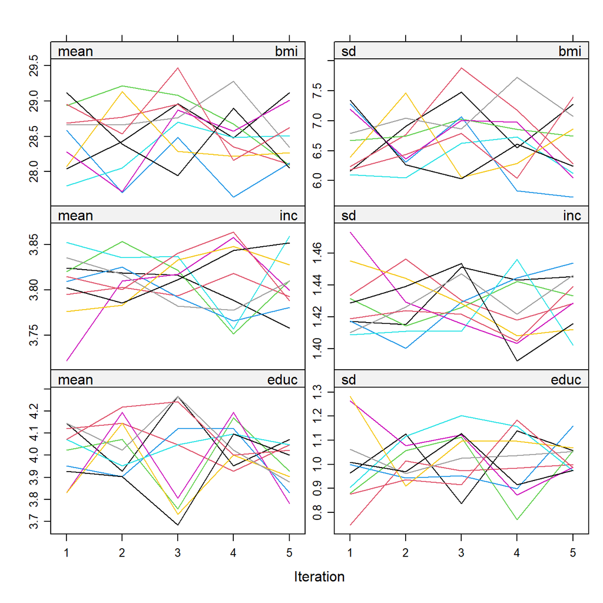

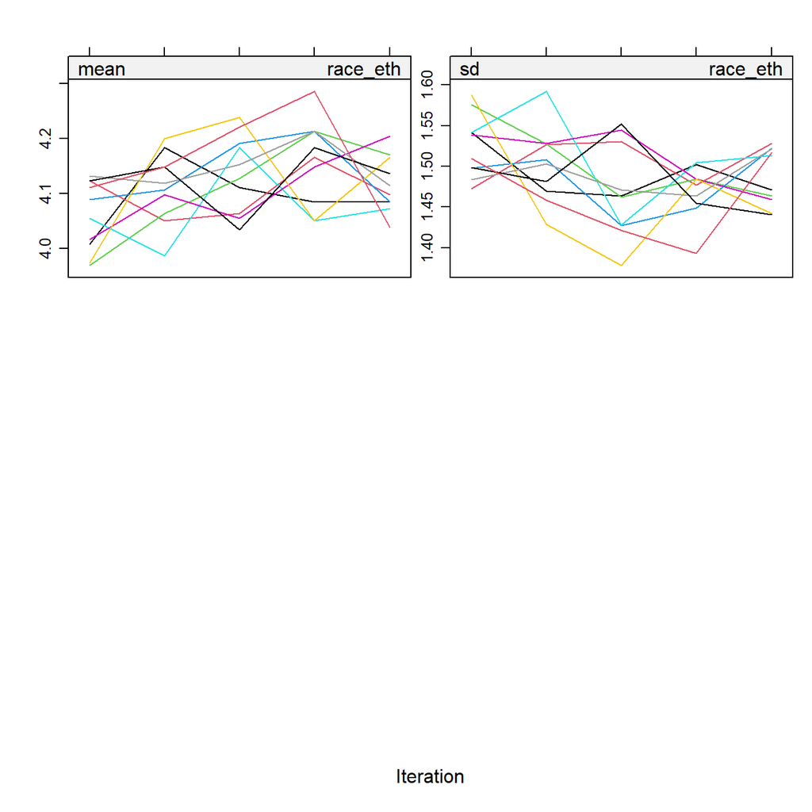

```r
plot(imp)
```

Shows how many imputations were done. It also shows total missingness, which imputation method was used for each variable (because you wouldn’t want to use a normal distribution for a categorical variable!!).

It also shows the sequence of how each variable is visited (or imputed, the default is left to right).

We may want to make sure imputed values are plausible by having a look. For instance, are the BMI values outside of the range of the data.

```r
head(imp$imp$badhealth)
```

```r
summary(imp$imp$badhealth)
```

```
## Length  Class   Mode
##      0   NULL   NULL
```

```r
summary(brfss20$bmi)
```

```
##    Min. 1st Qu.  Median    Mean 3rd Qu.    Max.    NA's
##   12.83   23.91   27.10   28.11   31.01   93.97    1105
```

```r
head(imp$imp$inc)
```

|  | 1 | 2 | 3 | 4 | 5 | 6 | 7 | 8 | 9 | 10 |
| --- | --- | --- | --- | --- | --- | --- | --- | --- | --- | --- |
| 19 | 1 | 4 | 1 | 5 | 2 | 3 | 2 | 1 | 1 | 1 |
| 20 | 5 | 2 | 1 | 3 | 4 | 4 | 2 | 5 | 5 | 5 |
| 23 | 1 | 2 | 2 | 1 | 1 | 1 | 1 | 1 | 5 | 1 |
| 24 | 5 | 5 | 5 | 1 | 5 | 5 | 4 | 5 | 5 | 5 |
| 26 | 4 | 3 | 5 | 1 | 2 | 4 | 5 | 5 | 1 | 3 |
| 45 | 2 | 2 | 5 | 4 | 2 | 4 | 2 | 5 | 1 | 3 |

```r
summary(imp$imp$inc)
```

```
##        1               2               3              4               5
##  Min.   :1.000   Min.   :1.000   Min.   :1.00   Min.   :1.000   Min.   :1.000
##  1st Qu.:2.000   1st Qu.:2.000   1st Qu.:2.00   1st Qu.:2.000   1st Qu.:3.000
##  Median :4.000   Median :5.000   Median :5.00   Median :5.000   Median :5.000
##  Mean   :3.758   Mean   :3.793   Mean   :3.81   Mean   :3.781   Mean   :3.859
##  3rd Qu.:5.000   3rd Qu.:5.000   3rd Qu.:5.00   3rd Qu.:5.000   3rd Qu.:5.000
##  Max.   :5.000   Max.   :5.000   Max.   :5.00   Max.   :5.000   Max.   :5.000
##        6             7               8              9               10
##  Min.   :1.0   Min.   :1.000   Min.   :1.00   Min.   :1.000   Min.   :1.000
##  1st Qu.:2.0   1st Qu.:2.000   1st Qu.:2.00   1st Qu.:3.000   1st Qu.:2.000
##  Median :4.0   Median :5.000   Median :5.00   Median :5.000   Median :5.000
##  Mean   :3.8   Mean   :3.828   Mean   :3.81   Mean   :3.852   Mean   :3.788
##  3rd Qu.:5.0   3rd Qu.:5.000   3rd Qu.:5.00   3rd Qu.:5.000   3rd Qu.:5.000
##  Max.   :5.0   Max.   :5.000   Max.   :5.00   Max.   :5.000   Max.   :5.000
```

We can also do some plotting. For instance if we want to see how the observed and imputed values of bmi look with respect to race, we can do:

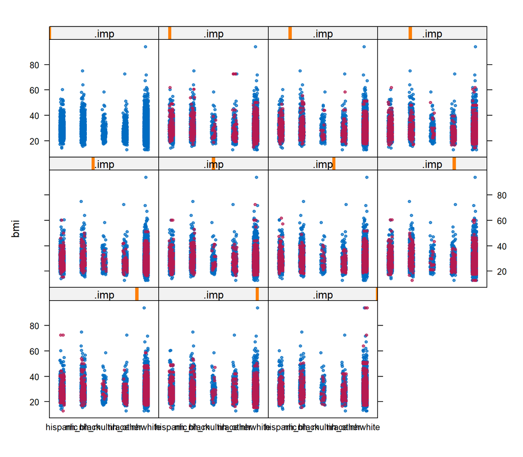

```r
library(lattice)
stripplot(imp,bmi~race_eth|.imp, pch=20)
```

```r
#stripplot(imp, badhealth~agec|.imp, pch=20)
```

This plot shows that the bmi values correspond well with the observed data, *so they are probably plausible values*.

If we want to get our new, imputed data, we can use the `complete()` function, which by default extracts the first imputed data set. If we want a different one, we can do `complete(imp, action=3)` for example, to get the third imputed data set.

```r
dat.imp<-complete(imp, action = 1)
head(dat.imp, n=10)
```

|  | bmi | inc | agec | educ | race_eth |
| --- | --- | --- | --- | --- | --- |
| 1 | 33.36 | 2 | (29,39] | 2hsgrad | hispanic |
| 2 | 32.92 | 5 | (39,59] | 4colgrad | nhwhite |
| 3 | 37.86 | 3 | (59,79] | 2hsgrad | nhwhite |
| 4 | 29.84 | 5 | (79,99] | 2hsgrad | nhwhite |
| 5 | 31.62 | 5 | (29,39] | 3somecol | nh_other |
| 6 | 30.81 | 5 | (59,79] | 4colgrad | nhwhite |
| 7 | 30.67 | 5 | (59,79] | 4colgrad | nhwhite |
| 8 | 22.86 | 5 | (29,39] | 3somecol | hispanic |
| 9 | 48.08 | 5 | (29,39] | 4colgrad | nh_black |
| 10 | 26.61 | 5 | (59,79] | 4colgrad | nhwhite |

```r
#Compare to the original data
head(brfss20[,c("bmi", "inc", "agec","educ","race_eth")], n=10)
```

| bmi | inc | agec | educ | race_eth |
| --- | --- | --- | --- | --- |
| 33.36 | 2 | (29,39] | 2hsgrad | hispanic |
| 32.92 | 5 | (39,59] | 4colgrad | nhwhite |
| NA | 3 | (59,79] | 2hsgrad | nhwhite |
| 29.84 | 5 | (79,99] | 2hsgrad | nhwhite |
| 31.62 | 5 | (29,39] | 3somecol | nh_other |
| 30.81 | 5 | (59,79] | 4colgrad | nhwhite |
| 30.67 | 5 | (59,79] | 4colgrad | nhwhite |
| 22.86 | 5 | (29,39] | 3somecol | hispanic |
| 48.08 | 5 | (29,39] | 4colgrad | nh_black |
| 26.61 | 5 | (59,79] | 4colgrad | nhwhite |

While the first few cases don’t show much missingness, we can coax some more interesting cases out and compare the original data to the imputed:

```r
head(dat.imp[is.na(brfss20$bmi)==T,], n=10)
```

|  | bmi | inc | agec | educ | race_eth |
| --- | --- | --- | --- | --- | --- |
| 3 | 37.86 | 3 | (59,79] | 2hsgrad | nhwhite |
| 29 | 26.94 | 5 | (59,79] | 2hsgrad | nhwhite |
| 47 | 25.84 | 5 | (39,59] | 4colgrad | nhwhite |
| 62 | 29.05 | 5 | (59,79] | 4colgrad | nhwhite |
| 70 | 22.65 | 5 | (79,99] | 4colgrad | nhwhite |
| 98 | 21.95 | 5 | (39,59] | 4colgrad | nhwhite |
| 118 | 28.29 | 5 | (59,79] | 2hsgrad | nhwhite |
| 124 | 27.34 | 4 | (39,59] | 0Prim | hispanic |
| 127 | 24.80 | 5 | (59,79] | 4colgrad | nhwhite |
| 139 | 29.26 | 2 | (59,79] | 0Prim | hispanic |

```r
head(brfss20[is.na(brfss20$bmi)==T,c("bmi", "inc", "agec","educ","race_eth")], n=10)
```

| bmi | inc | agec | educ | race_eth |
| --- | --- | --- | --- | --- |
| NA | 3 | (59,79] | 2hsgrad | nhwhite |
| NA | 5 | (59,79] | 2hsgrad | nhwhite |
| NA | NA | (39,59] | 4colgrad | nhwhite |
| NA | NA | (59,79] | 4colgrad | nhwhite |
| NA | NA | (79,99] | 4colgrad | nhwhite |
| NA | 5 | (39,59] | 4colgrad | nhwhite |
| NA | NA | (59,79] | 2hsgrad | nhwhite |
| NA | NA | (39,59] | 0Prim | hispanic |
| NA | NA | (59,79] | 4colgrad | nhwhite |
| NA | NA | (59,79] | 0Prim | hispanic |

### Analyzing the imputed data

Here I look at a linear model for bmi:

```r
#Now, I will see the variability in the 5 different imputations for each outcom
fit.bmi<-with(data=imp ,expr=lm(bmi~factor(inc)+agec+educ+race_eth))
fit.bmi
```

```
## call :
## with.mids(data = imp, expr = lm(bmi ~ factor(inc) + agec + educ +
##     race_eth))
##
## call1 :
## mice(data = dat2[, c("bmi", "inc", "agec", "educ", "race_eth")],
##     m = 10, seed = 22)
##
## nmis :
##      bmi      inc     agec     educ race_eth
##     1105     2021        0       41      235
##
## analyses :
## [[1]]
##
## Call:
## lm(formula = bmi ~ factor(inc) + agec + educ + race_eth)
##
## Coefficients:
##          (Intercept)          factor(inc)2          factor(inc)3
##              27.8525                0.2198                0.4682
##         factor(inc)4          factor(inc)5           agec(29,39]
##               0.2922               -0.3520                2.1181
##          agec(39,59]           agec(59,79]           agec(79,99]
##               2.8609                2.1037               -0.4230
##          educ1somehs           educ2hsgrad          educ3somecol
##              -0.7776               -0.9511               -0.7128
##         educ4colgrad      race_ethnh_black  race_ethnh_multirace
##              -1.8703                1.2776               -1.0894
##     race_ethnh_other       race_ethnhwhite
##              -1.1273               -0.2916
##
##
## [[2]]
##
## Call:
## lm(formula = bmi ~ factor(inc) + agec + educ + race_eth)
##
## Coefficients:
##          (Intercept)          factor(inc)2          factor(inc)3
```

[output cut: 156 more lines]

```
## lm(formula = bmi ~ factor(inc) + agec + educ + race_eth)
##
## Coefficients:
##          (Intercept)          factor(inc)2          factor(inc)3
##             26.78971              -0.06103              -0.06199
##         factor(inc)4          factor(inc)5           agec(29,39]
##             -0.22498              -0.72902               2.06179
##          agec(39,59]           agec(59,79]           agec(79,99]
##              3.06445               2.06600              -0.25356
##          educ1somehs           educ2hsgrad          educ3somecol
##             -0.02002              -0.00946               0.27751
##         educ4colgrad      race_ethnh_black  race_ethnh_multirace
##             -0.83065               1.29974              -0.76192
##     race_ethnh_other       race_ethnhwhite
##             -1.08968               0.17213
```

### variation in bmi

```r
with (data=imp, exp=(sd(bmi)))
```

```
## call :
## with.mids(data = imp, expr = (sd(bmi)))
##
## call1 :
## mice(data = dat2[, c("bmi", "inc", "agec", "educ", "race_eth")],
##     m = 10, seed = 22)
##
## nmis :
##      bmi      inc     agec     educ race_eth
##     1105     2021        0       41      235
##
## analyses :
## [[1]]
## [1] 6.327508
##
## [[2]]
## [1] 6.200309
##
## [[3]]
## [1] 6.254287
##
## [[4]]
## [1] 6.141304
##
## [[5]]
## [1] 6.184319
##
## [[6]]
## [1] 6.181014
##
## [[7]]
## [1] 6.268828
##
## [[8]]
## [1] 6.294114
##
## [[9]]
## [1] 6.196084
##
## [[10]]
## [1] 6.336522
```

### Frequency table for income

```r
with (data=imp, exp=(prop.table(table(inc))))
```

```
## call :
## with.mids(data = imp, expr = (prop.table(table(inc))))
##
## call1 :
## mice(data = dat2[, c("bmi", "inc", "agec", "educ", "race_eth")],
##     m = 10, seed = 22)
##
## nmis :
##      bmi      inc     agec     educ race_eth
##     1105     2021        0       41      235
##
## analyses :
## [[1]]
## inc
##      1      2      3      4      5
## 0.0706 0.1487 0.0834 0.1254 0.5719
##
## [[2]]
## inc
##      1      2      3      4      5
## 0.0707 0.1438 0.0875 0.1245 0.5735
##
## [[3]]
## inc
##      1      2      3      4      5
## 0.0708 0.1442 0.0846 0.1251 0.5753
##
## [[4]]
## inc
##      1      2      3      4      5
## 0.0715 0.1467 0.0831 0.1238 0.5749
##
## [[5]]
## inc
##      1      2      3      4      5
## 0.0684 0.1435 0.0856 0.1249 0.5776
##
## [[6]]
## inc
##      1      2      3      4      5
## 0.0712 0.1440 0.0830 0.1295 0.5723
##
## [[7]]
## inc
##      1      2      3      4      5
## 0.0686 0.1457 0.0848 0.1255 0.5754
##
## [[8]]
## inc
##      1      2      3      4      5
## 0.0713 0.1449 0.0833 0.1237 0.5768
##
## [[9]]
## inc
##      1      2      3      4      5
## 0.0696 0.1432 0.0841 0.1255 0.5776
##
## [[10]]
## inc
##      1      2      3      4      5
## 0.0711 0.1447 0.0861 0.1239 0.5742
```

### Frequency table for race/ethnicty

```r
with (data=imp, exp=(prop.table(table(race_eth))))
```

```
## call :
## with.mids(data = imp, expr = (prop.table(table(race_eth))))
##
## call1 :
## mice(data = dat2[, c("bmi", "inc", "agec", "educ", "race_eth")],
##     m = 10, seed = 22)
##
## nmis :
##      bmi      inc     agec     educ race_eth
##     1105     2021        0       41      235
##
## analyses :
## [[1]]
## race_eth
##     hispanic     nh_black nh_multirace     nh_other      nhwhite
##       0.1082       0.0996       0.0183       0.0474       0.7265
##
## [[2]]
## race_eth
##     hispanic     nh_black nh_multirace     nh_other      nhwhite
##       0.1088       0.0991       0.0181       0.0466       0.7274
##
## [[3]]
## race_eth
##     hispanic     nh_black nh_multirace     nh_other      nhwhite
##       0.1083       0.0992       0.0179       0.0470       0.7276
##
## [[4]]
## race_eth
##     hispanic     nh_black nh_multirace     nh_other      nhwhite
##       0.1089       0.0989       0.0180       0.0473       0.7269
##
## [[5]]
## race_eth
##     hispanic     nh_black nh_multirace     nh_other      nhwhite
##       0.1089       0.0987       0.0184       0.0474       0.7266
##
## [[6]]
## race_eth
##     hispanic     nh_black nh_multirace     nh_other      nhwhite
##       0.1085       0.0987       0.0178       0.0471       0.7279
##
## [[7]]
## race_eth
##     hispanic     nh_black nh_multirace     nh_other      nhwhite
##       0.1080       0.0995       0.0181       0.0470       0.7274
##
## [[8]]
## race_eth
##     hispanic     nh_black nh_multirace     nh_other      nhwhite
##       0.1087       0.0993       0.0177       0.0468       0.7275
##
## [[9]]
## race_eth
##     hispanic     nh_black nh_multirace     nh_other      nhwhite
##       0.1080       0.0995       0.0183       0.0473       0.7269
##
## [[10]]
## race_eth
##     hispanic     nh_black nh_multirace     nh_other      nhwhite
##       0.1086       0.0996       0.0180       0.0475       0.7263
```

### Frequency table for education

```r
with (data=imp, exp=(prop.table(table(educ))))
```

```
## call :
## with.mids(data = imp, expr = (prop.table(table(educ))))
##
## call1 :
## mice(data = dat2[, c("bmi", "inc", "agec", "educ", "race_eth")],
##     m = 10, seed = 22)
##
## nmis :
##      bmi      inc     agec     educ race_eth
##     1105     2021        0       41      235
##
## analyses :
## [[1]]
## educ
##    0Prim  1somehs  2hsgrad 3somecol 4colgrad
##   0.0199   0.0396   0.2395   0.2601   0.4409
##
## [[2]]
## educ
##    0Prim  1somehs  2hsgrad 3somecol 4colgrad
##   0.0198   0.0397   0.2396   0.2601   0.4408
##
## [[3]]
## educ
##    0Prim  1somehs  2hsgrad 3somecol 4colgrad
##   0.0199   0.0397   0.2395   0.2604   0.4405
##
## [[4]]
## educ
##    0Prim  1somehs  2hsgrad 3somecol 4colgrad
##   0.0199   0.0398   0.2399   0.2597   0.4407
##
## [[5]]
## educ
##    0Prim  1somehs  2hsgrad 3somecol 4colgrad
##   0.0199   0.0395   0.2395   0.2605   0.4406
##
## [[6]]
## educ
##    0Prim  1somehs  2hsgrad 3somecol 4colgrad
##   0.0198   0.0398   0.2399   0.2603   0.4402
##
## [[7]]
## educ
##    0Prim  1somehs  2hsgrad 3somecol 4colgrad
##   0.0199   0.0396   0.2399   0.2600   0.4406
##
## [[8]]
## educ
##    0Prim  1somehs  2hsgrad 3somecol 4colgrad
##   0.0198   0.0399   0.2396   0.2602   0.4405
##
## [[9]]
## educ
##    0Prim  1somehs  2hsgrad 3somecol 4colgrad
##   0.0198   0.0396   0.2399   0.2600   0.4407
##
## [[10]]
## educ
##    0Prim  1somehs  2hsgrad 3somecol 4colgrad
##   0.0199   0.0395   0.2396   0.2604   0.4406
```

Now we pool the separate models from each imputed data set:

```r
est.p<-pool(fit.bmi)
print(est.p)
```

```
## Class: mipo    m = 10
##                    term  m    estimate       ubar           b          t dfcom
## 1           (Intercept) 10 27.59389084 0.24281613 0.264839264 0.53413932  9983
## 2          factor(inc)2 10 -0.12392399 0.08006143 0.055426807 0.14103092  9983
## 3          factor(inc)3 10 -0.01363506 0.09992236 0.063797332 0.17009943  9983
## 4          factor(inc)4 10 -0.08616230 0.08760942 0.052559545 0.14542492  9983
## 5          factor(inc)5 10 -0.70620308 0.06948104 0.048786563 0.12314626  9983
## 6           agec(29,39] 10  2.09437077 0.05542056 0.007590811 0.06377045  9983
## 7           agec(39,59] 10  2.79150770 0.04095151 0.017028401 0.05968275  9983
## 8           agec(59,79] 10  2.03295169 0.04074866 0.011498844 0.05339739  9983
## 9           agec(79,99] 10 -0.40128033 0.08241559 0.007918676 0.09112613  9983
## 10          educ1somehs 10 -0.49955786 0.28919757 0.166782949 0.47265881  9983
## 11          educ2hsgrad 10 -0.55330974 0.22230779 0.182496207 0.42305362  9983
## 12         educ3somecol 10 -0.25352496 0.22493938 0.139621080 0.37852257  9983
## 13         educ4colgrad 10 -1.37824134 0.22507429 0.184179194 0.42767140  9983
```

[output cut: 22 more lines]

```r
summary(est.p)
```

| term | estimate | std.error | statistic | df | p.value |
| --- | --- | --- | --- | --- | --- |
| (Intercept) | 27.59389084 | 0.7308484 | 37.75597304 | 30.05489 | 0.000000e+00 |
| factor(inc)2 | -0.12392399 | 0.3755408 | -0.32998806 | 47.74970 | 7.428524e-01 |
| factor(inc)3 | -0.01363506 | 0.4124311 | -0.03306022 | 52.40332 | 9.737522e-01 |
| factor(inc)4 | -0.08616230 | 0.3813462 | -0.22594245 | 56.40768 | 8.220629e-01 |
| factor(inc)5 | -0.70620308 | 0.3509220 | -2.01242175 | 46.99586 | 4.992609e-02 |
| agec(29,39] | 2.09437077 | 0.2525281 | 8.29361429 | 494.99534 | 8.881784e-16 |
| agec(39,59] | 2.79150770 | 0.2443005 | 11.42653096 | 90.16774 | 0.000000e+00 |
| agec(59,79] | 2.03295169 | 0.2310788 | 8.79765742 | 157.08630 | 2.220446e-15 |
| agec(79,99] | -0.40128033 | 0.3018711 | -1.32931038 | 888.09627 | 1.840870e-01 |
| educ1somehs | -0.49955786 | 0.6875019 | -0.72662765 | 59.15912 | 4.703195e-01 |

[output cut: 7 more lines]

We need to pay attention to the `fmi` column and the `lambda` column. These convey information about how much the missingness of each particular variable affects the model coefficients.

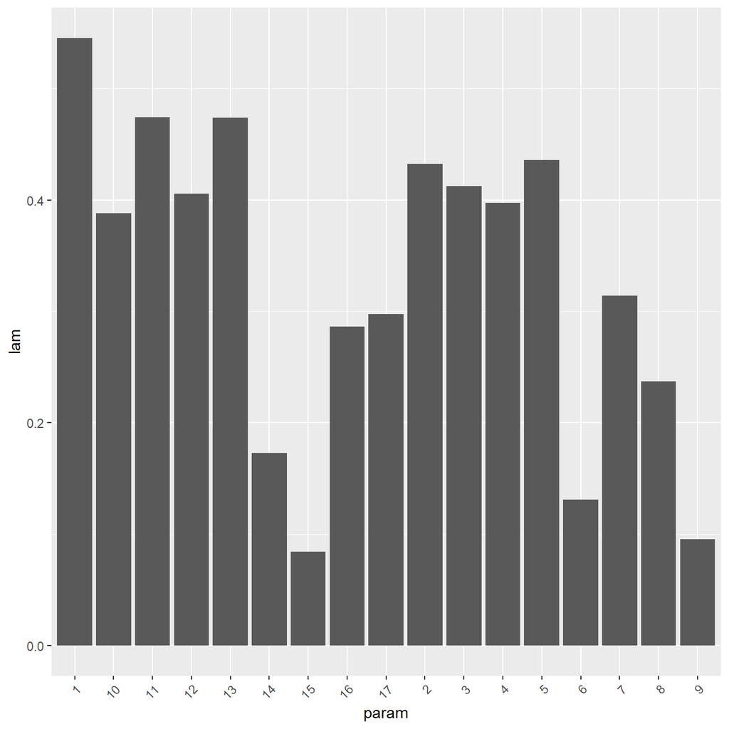

```r
lam<-data.frame(lam=est.p$pooled$lambda, param=row.names(est.p$pooled))

ggplot(data=lam,aes(x=param, y=lam))+geom_col()+theme(axis.text.x = element_text(angle = 45, hjust = 1))
```

It appears that a couple of the education variables and the income variables have large variances to them. This suggests that there may be noticeable variation in the resulting coefficient of the model, depending on which imputed data set we use.

We can also compare to the model fit on the original data, with missings eliminated:

```r
library(dplyr)
bnm<-brfss20%>%
  select(bmi, inc, agec, educ, race_eth)%>%
  filter(complete.cases(.))%>%
  as.data.frame()

summary(lm(bmi~factor(inc)+agec+educ+race_eth, bnm))
```

```
##
## Call:
## lm(formula = bmi ~ factor(inc) + agec + educ + race_eth, data = bnm)
##
## Residuals:
##     Min      1Q  Median      3Q     Max
## -15.721  -4.071  -0.954   2.893  64.068
##
## Coefficients:
##                      Estimate Std. Error t value Pr(>|t|)
## (Intercept)          27.56818    0.69429  39.707  < 2e-16 ***
## factor(inc)2          0.09522    0.34481   0.276  0.78245
## factor(inc)3          0.20964    0.38155   0.549  0.58273
## factor(inc)4          0.09079    0.35488   0.256  0.79809
## factor(inc)5         -0.63216    0.31723  -1.993  0.04633 *
## agec(29,39]           1.99905    0.27350   7.309 2.97e-13 ***
## agec(39,59]           2.61705    0.23786  11.002  < 2e-16 ***
## agec(59,79]           2.00950    0.23815   8.438  < 2e-16 ***
## agec(79,99]          -0.43776    0.35009  -1.250  0.21119
## educ1somehs          -0.57155    0.74506  -0.767  0.44304
## educ2hsgrad          -0.48404    0.66548  -0.727  0.46703
## educ3somecol         -0.24699    0.66694  -0.370  0.71115
## educ4colgrad         -1.37526    0.66649  -2.063  0.03911 *
## race_ethnh_black      1.54857    0.32496   4.765 1.92e-06 ***
## race_ethnh_multirace -0.38261    0.58301  -0.656  0.51167
## race_ethnh_other     -1.32266    0.41765  -3.167  0.00155 **
## race_ethnhwhite      -0.03643    0.25413  -0.143  0.88601
## ---
## Signif. codes:  0 '***' 0.001 '**' 0.01 '*' 0.05 '.' 0.1 ' ' 1
##
## Residual standard error: 6.09 on 7343 degrees of freedom
## Multiple R-squared:  0.04421,    Adjusted R-squared:  0.04213
## F-statistic: 21.23 on 16 and 7343 DF,  p-value: < 2.2e-16
```

### Compare imputed model to original data

Here, I compare the coefficients from the model where we eliminated all missing data to the one that we fit on the imputed data:

```r
fit1<-lm(bmi~factor(inc)+agec+educ+race_eth, data=brfss20)
summary(fit1)
```

```
##
## Call:
## lm(formula = bmi ~ factor(inc) + agec + educ + race_eth, data = brfss20)
##
## Residuals:
##     Min      1Q  Median      3Q     Max
## -15.721  -4.071  -0.954   2.893  64.068
##
## Coefficients:
##                      Estimate Std. Error t value Pr(>|t|)
## (Intercept)          27.56818    0.69429  39.707  < 2e-16 ***
## factor(inc)2          0.09522    0.34481   0.276  0.78245
## factor(inc)3          0.20964    0.38155   0.549  0.58273
## factor(inc)4          0.09079    0.35488   0.256  0.79809
## factor(inc)5         -0.63216    0.31723  -1.993  0.04633 *
## agec(29,39]           1.99905    0.27350   7.309 2.97e-13 ***
## agec(39,59]           2.61705    0.23786  11.002  < 2e-16 ***
## agec(59,79]           2.00950    0.23815   8.438  < 2e-16 ***
## agec(79,99]          -0.43776    0.35009  -1.250  0.21119
## educ1somehs          -0.57155    0.74506  -0.767  0.44304
## educ2hsgrad          -0.48404    0.66548  -0.727  0.46703
## educ3somecol         -0.24699    0.66694  -0.370  0.71115
## educ4colgrad         -1.37526    0.66649  -2.063  0.03911 *
## race_ethnh_black      1.54857    0.32496   4.765 1.92e-06 ***
## race_ethnh_multirace -0.38261    0.58301  -0.656  0.51167
## race_ethnh_other     -1.32266    0.41765  -3.167  0.00155 **
## race_ethnhwhite      -0.03643    0.25413  -0.143  0.88601
## ---
## Signif. codes:  0 '***' 0.001 '**' 0.01 '*' 0.05 '.' 0.1 ' ' 1
##
## Residual standard error: 6.09 on 7343 degrees of freedom
##   (2640 observations deleted due to missingness)
## Multiple R-squared:  0.04421,    Adjusted R-squared:  0.04213
## F-statistic: 21.23 on 16 and 7343 DF,  p-value: < 2.2e-16
```

```r
fit.imp<-lm(bmi~factor(inc)+agec+educ+race_eth, data=dat.imp)
summary(fit.imp)
```

```
##
## Call:
## lm(formula = bmi ~ factor(inc) + agec + educ + race_eth, data = dat.imp)
##
## Residuals:
##     Min      1Q  Median      3Q     Max
## -16.515  -4.105  -1.052   2.908  64.261
##
## Coefficients:
##                      Estimate Std. Error t value Pr(>|t|)
## (Intercept)           27.8525     0.4993  55.780  < 2e-16 ***
## factor(inc)2           0.2198     0.2851   0.771  0.44079
## factor(inc)3           0.4682     0.3207   1.460  0.14438
## factor(inc)4           0.2922     0.2992   0.976  0.32885
## factor(inc)5          -0.3520     0.2659  -1.324  0.18556
## agec(29,39]            2.1181     0.2386   8.879  < 2e-16 ***
## agec(39,59]            2.8609     0.2050  13.958  < 2e-16 ***
## agec(59,79]            2.1037     0.2045  10.287  < 2e-16 ***
## agec(79,99]           -0.4230     0.2908  -1.455  0.14577
## educ1somehs           -0.7776     0.5449  -1.427  0.15356
## educ2hsgrad           -0.9511     0.4775  -1.992  0.04641 *
## educ3somecol          -0.7128     0.4804  -1.484  0.13794
## educ4colgrad          -1.8703     0.4803  -3.894 9.93e-05 ***
## race_ethnh_black       1.2776     0.2783   4.590 4.49e-06 ***
## race_ethnh_multirace  -1.0894     0.4984  -2.186  0.02886 *
## race_ethnh_other      -1.1273     0.3470  -3.249  0.00116 **
## race_ethnhwhite       -0.2916     0.2189  -1.332  0.18279
## ---
## Signif. codes:  0 '***' 0.001 '**' 0.01 '*' 0.05 '.' 0.1 ' ' 1
##
## Residual standard error: 6.182 on 9983 degrees of freedom
## Multiple R-squared:  0.047,  Adjusted R-squared:  0.04548
## F-statistic: 30.77 on 16 and 9983 DF,  p-value: < 2.2e-16
```